# Differential Gene Expression of FLC1 and EGTA effects with interactions

Edward Wallace

2024-12-06

# Summary

Differential Gene Expression of WT vs delta and EGTA vs none with interaction, at 37°C in YPD samples, using DESeq2,

This analysis produces files focused on the interaction term:

- `deseq_df_FLC1EGTAinteraction.txt`
- `deglist_FLC1EGTAinteraction_up2x_FDR5.txt`
- `deglist_FLC1EGTAinteraction_down2x_FDR5.txt`

This analysis confirms that there is a significant interaction between the strain and the effect of EGTA. Many genes are differently effect by EGTA in the presence or absence of FLC1. There are noticeable signals of:

- genes involved in divalent cations (CTR4, FRE, etc.)
- chitin synthesis (CHS6, CHS7)
- some secreted or cell surface proteins (CIG1, etc)
- transporters (HXS1, etc)

## Load count data from shared script load_count_data.Rmd

# Load and organise count data

`load_count_data.Rmd` is just to load and organise the raw count data in R, as well as loading libraries for data analysis. Other scripts can just run this one instead of duplicating code, especially scripts for differential gene expression analysis.

This runs *after* `QC_PCA.Rmd`, which does the organisation. This just loads the organised counts from the file `results/summaries/counts_bysamplecode.txt`.

## Load the organised counts

```r
counts_all <-
  here::here("results", "summaries", "counts_bysamplecode.txt") %>%
  readr::read_tsv(comment = "#",
                  col_types = "ciiiiiiiiiiiiiiiiiiiiiiiiiiiiiii")   %>%
  magrittr::set_rownames(.$Gene)
counts_all
```

```
## # A tibble: 6,795 × 32
##    Gene       Length WT_30_Y_1 WT_30_Y_2 WT_30_Y_3 FL_30_Y_1 FL_30_Y_2 FL_30_Y_3
##  * <chr>       <int>     <int>     <int>     <int>     <int>     <int>     <int>
##  1 CNAG_00002   1027       322       378       346       310       309       174
##  2 CNAG_00003   2397        19        43        27        54        52        33
##  3 CNAG_00004   3424        94        80        83       102        94        65
##  4 CNAG_00005   2162       462       399       385       378       344       310
##  5 CNAG_00006   1450      1019      1533      1256      1505      1359       778
##  6 CNAG_00007   2294       471       703       579       476       407       284
##  7 CNAG_00008   4351       141       226       206       272       259       164
##  8 CNAG_00009   1794       160       162       187       323       250       171
##  9 CNAG_00010   3879       195       199       242       362       272       159
## 10 CNAG_00011   2037        85       117       114       162       139        81
## # ℹ 6,785 more rows
## # ℹ 24 more variables: WT_37_Y_1 <int>, WT_37_Y_2 <int>, WT_37_Y_3 <int>,
## #   FL_37_Y_1 <int>, FL_37_Y_2 <int>, FL_37_Y_3 <int>, WT_37_C_1 <int>,
## #   WT_37_C_2 <int>, WT_37_C_3 <int>, FL_37_C_1 <int>, FL_37_C_2 <int>,
## #   FL_37_C_3 <int>, WT_37_E_1 <int>, WT_37_E_2 <int>, WT_37_E_3 <int>,
## #   FL_37_E_1 <int>, FL_37_E_2 <int>, FL_37_E_3 <int>, WT_37_CE_1 <int>,
## #   WT_37_CE_2 <int>, WT_37_CE_3 <int>, FL_37_CE_1 <int>, FL_37_CE_2 <int>, …
```

## Load the sample sheet

```r
sample_sheet <-
  here::here("input", "experiment",
             "CryptoRNAseqFLC1SampleKey.csv") %>%
  readr::read_csv(comment = "#", col_types = "ccccccc") %>%
  dplyr::mutate(Condition = stringr::str_sub(SampleName,start = 1L, end = -3L)) %>%
  dplyr::transmute(SampleID = as_factor(SampleID),
                   SampleName = as_factor(SampleName),
                   Condition = as_factor(Condition),
                   FLC1 = factor(FLC1, levels = c("delta", "WT")),
                   Temperature = factor(Temperature, levels = c("30", "37")),
                   Media = as_factor(Media),
                   BioRep = as_factor(BioRep))

sample_sheet
```

```
## # A tibble: 30 × 7
##    SampleID SampleName Condition FLC1  Temperature Media BioRep
##    <fct>    <fct>      <fct>     <fct> <fct>       <fct> <fct>
##  1 1        WT_30_Y_1  WT_30_Y   WT    30          YPD   1
##  2 2        WT_30_Y_2  WT_30_Y   WT    30          YPD   2
##  3 3        WT_30_Y_3  WT_30_Y   WT    30          YPD   3
##  4 4        FL_30_Y_1  FL_30_Y   delta 30          YPD   1
##  5 5        FL_30_Y_2  FL_30_Y   delta 30          YPD   2
##  6 6        FL_30_Y_3  FL_30_Y   delta 30          YPD   3
##  7 7        WT_37_Y_1  WT_37_Y   WT    37          YPD   1
##  8 8        WT_37_Y_2  WT_37_Y   WT    37          YPD   2
##  9 9        WT_37_Y_3  WT_37_Y   WT    37          YPD   3
## 10 10       FL_37_Y_1  FL_37_Y   delta 37          YPD   1
## # ℹ 20 more rows
```

## Load H99 Gene information

```r
gene_info_df <-
  here::here("input", "annotation",
             "H99_geneinfo_FungiDB59.txt") %>%
  readr::read_tsv(comment = "#")  %>%
  dplyr::rename(gene = GeneID, geneName = GeneName)
```

# DESeq on a subset of data, only 37C in YPD

```r
sample_sheet_FLC1EGTAinteraction <-
  dplyr::filter(sample_sheet,
                Temperature == "37", Media %in% c("YPD", "YPD_EGTA")) %>%
  dplyr::mutate(EGTA = factor(Media,
                              levels = c("YPD","YPD_EGTA"),
                              labels = c("No","Yes")))

dds_FLC1EGTAinteraction <-
  DESeqDataSetFromMatrix(
    countData = counts_all %>%
      dplyr::select(sample_sheet_FLC1EGTAinteraction$SampleName) %>%
      magrittr::set_rownames(counts_all$Gene),
    colData = sample_sheet_FLC1EGTAinteraction,
    design = ~ FLC1 + EGTA + FLC1:EGTA) %>%
  DESeq()
dds_FLC1EGTAinteraction
```

```
## class: DESeqDataSet
## dim: 6795 12
## metadata(1): version
## assays(4): counts mu H cooks
## rownames(6795): CNAG_00002 CNAG_00003 ... CNAG_14001 CNAG_14002
## rowData names(30): baseMean baseVar ... deviance maxCooks
## colnames(12): WT_37_Y_1 WT_37_Y_2 ... FL_37_E_2 FL_37_E_3
## colData names(9): SampleID SampleName ... EGTA sizeFactor
```

```r
results(dds_FLC1EGTAinteraction)
```

```
## log2 fold change (MLE): FLC1WT.EGTAYes
## Wald test p-value: FLC1WT.EGTAYes
## DataFrame with 6795 rows and 6 columns
##             baseMean log2FoldChange     lfcSE      stat    pvalue      padj
##            <numeric>      <numeric> <numeric> <numeric> <numeric> <numeric>
## CNAG_00002  400.9674      0.1399345  0.179243  0.780696  0.434982  0.649410
## CNAG_00003   47.4925      0.0855563  0.368796  0.231988  0.816547  0.907947
## CNAG_00004  105.9313     -0.3251376  0.247751 -1.312358  0.189399  0.398441
## CNAG_00005  611.1756      0.0557655  0.171906  0.324396  0.745638  0.866321
## CNAG_00006 1461.1956     -0.2255623  0.121761 -1.852493  0.063955  0.191837
## ...              ...            ...       ...       ...       ...       ...
## CNAG_08027 351.86661     -0.1660518  0.186061 -0.892458  0.372148  0.592751
## CNAG_08028 111.54293      0.1350196  0.243205  0.555169  0.578779  0.757098
## CNAG_08029  88.86867      0.1737661  0.283357  0.613242  0.539716  0.731083
## CNAG_14001 376.62772      0.0304671  0.182871  0.166604  0.867682  0.933162
## CNAG_14002   1.61966      0.7674574  1.831080  0.419128  0.675122  0.823105
```

```r
resultsNames(dds_FLC1EGTAinteraction)
```

```
## [1] "Intercept"        "FLC1_WT_vs_delta" "EGTA_Yes_vs_No"   "FLC1WT.EGTAYes"
```

```r
deseq_df_FLC1EGTAinteraction <-
  biobroom::tidy.DESeqDataSet(dds_FLC1EGTAinteraction) %>%
  dplyr::filter(term == "FLC1WT.EGTAYes") %>%
  dplyr::left_join(gene_info_df,
                   by = "gene") %>%
  dplyr::select(gene,
                geneName,
                baseMean,
                log2FC = estimate,
                stderror,
                padj = p.adjusted)
```

## List DEGs most UP in WT vs delta

We cut off at 2x changes with 5% FDR here.

```r
# Make data frames of DEGs up and down, arranged by log2FC
DEGdf_interact_up2x_FDR5 <-
  dplyr::filter(deseq_df_FLC1EGTAinteraction,
                log2FC > 1, padj < 0.05) %>%
  dplyr::arrange(desc(log2FC))
print(DEGdf_interact_up2x_FDR5, n = 20)
```

```
## # A tibble: 92 × 6
##    gene       geneName baseMean log2FC stderror     padj
##    <chr>      <chr>       <dbl>  <dbl>    <dbl>    <dbl>
##  1 CNAG_00979 CTR4     13005.     4.64    0.233 1.51e-84
##  2 CNAG_01560 <NA>         4.64   4.50    1.51  1.96e- 2
##  3 CNAG_00749 <NA>        29.3    3.18    0.706 1.16e- 4
##  4 CNAG_02775 BIM1     10946.     2.69    0.169 2.42e-54
##  5 CNAG_07399 <NA>        27.4    2.67    0.610 2.00e- 4
##  6 CNAG_07648 <NA>        75.7    2.61    0.327 1.69e-13
##  7 CNAG_00876 FRE7       404.     2.53    0.219 2.31e-28
##  8 CNAG_07795 <NA>         8.22   2.52    0.859 2.20e- 2
##  9 CNAG_05075 <NA>        65.2    2.51    0.697 3.35e- 3
## 10 CNAG_01506 <NA>        99.8    2.11    0.351 7.61e- 8
## 11 CNAG_02217 CHS7       750.     2.00    0.209 2.28e-19
## 12 CNAG_01668 <NA>       109.     1.98    0.352 6.30e- 7
## 13 CNAG_05412 <NA>       248.     1.85    0.241 1.71e-12
## 14 CNAG_06372 <NA>       283.     1.84    0.223 2.24e-14
## 15 CNAG_03980 <NA>        20.3    1.72    0.578 2.00e- 2
## 16 CNAG_05032 <NA>       187.     1.70    0.309 1.19e- 6
## 17 CNAG_03384 <NA>        40.4    1.69    0.465 3.01e- 3
## 18 CNAG_06052 GAL7        86.2    1.66    0.314 3.34e- 6
## 19 CNAG_07334 FRE4      2534.     1.66    0.199 8.67e-15
## 20 CNAG_05411 LPI9      1652.     1.60    0.183 4.50e-16
## # ℹ 72 more rows
```

Print the top 20 *named* DEGs

```r
DEGdf_interact_up2x_FDR5 %>%
  dplyr::filter(!is.na(geneName)) %>%
  print(n = 20)
```

```
## # A tibble: 18 × 6
##    gene       geneName baseMean log2FC stderror     padj
##    <chr>      <chr>       <dbl>  <dbl>    <dbl>    <dbl>
##  1 CNAG_00979 CTR4      13005.    4.64    0.233 1.51e-84
##  2 CNAG_02775 BIM1      10946.    2.69    0.169 2.42e-54
##  3 CNAG_00876 FRE7        404.    2.53    0.219 2.31e-28
##  4 CNAG_02217 CHS7        750.    2.00    0.209 2.28e-19
##  5 CNAG_06052 GAL7         86.2   1.66    0.314 3.34e- 6
##  6 CNAG_07334 FRE4       2534.    1.66    0.199 8.67e-15
##  7 CNAG_05411 LPI9       1652.    1.60    0.183 4.50e-16
##  8 CNAG_06051 GAL1        190.    1.52    0.215 1.07e-10
##  9 CNAG_06745 H3        18642.    1.52    0.246 2.78e- 8
## 10 CNAG_04215 MET3       3502.    1.28    0.475 3.80e- 2
## 11 CNAG_05372 BLP5       4616.    1.27    0.371 5.58e- 3
## 12 CNAG_02870 MET7        493.    1.27    0.162 5.51e-13
## 13 CNAG_06487 CHS6        787.    1.20    0.171 1.56e-10
## 14 CNAG_07701 CTR1       1799.    1.20    0.229 5.05e- 6
## 15 CNAG_07448 DUR3         77.6   1.12    0.377 2.05e- 2
## 16 CNAG_01721 HEM3       1101.    1.07    0.208 6.99e- 6
## 17 CNAG_03212 HCM101      252.    1.03    0.207 1.51e- 5
## 18 CNAG_03498 FRE201      189.    1.01    0.338 1.88e- 2
```

## List DEGs most DOWN in WT vs delta

```r
# Make data frames of DEGs up and down, arranged by log2FC
DEGdf_interact_down2x_FDR5 <-
  dplyr::filter(deseq_df_FLC1EGTAinteraction,
                log2FC < -1, padj < 0.05) %>%
  dplyr::arrange(log2FC)
print(DEGdf_interact_down2x_FDR5, n = 20)
```

```
## # A tibble: 280 × 6
##    gene       geneName baseMean log2FC stderror     padj
##    <chr>      <chr>       <dbl>  <dbl>    <dbl>    <dbl>
##  1 CNAG_07912 <NA>         3.60  -5.31    1.91  3.18e- 2
##  2 CNAG_00091 <NA>       533.    -4.09    0.240 6.51e-62
##  3 CNAG_04469 <NA>        54.3   -4.08    0.554 1.50e-11
##  4 CNAG_01653 CIG1      1412.    -3.99    0.381 3.11e-23
##  5 CNAG_04106 <NA>        84.5   -3.39    0.381 1.36e-16
##  6 CNAG_06109 <NA>       513.    -3.18    0.226 5.21e-42
##  7 CNAG_04877 <NA>        13.4   -3.18    0.864 2.59e- 3
##  8 CNAG_01102 <NA>       412.    -3.14    0.220 4.67e-43
##  9 CNAG_03398 ZIP2       109.    -3.11    0.333 1.95e-18
## 10 CNAG_03408 <NA>       322.    -3.09    0.219 2.10e-42
## 11 CNAG_04704 <NA>        34.5   -3.06    0.723 3.48e- 4
## 12 CNAG_07874 <NA>        34.4   -3.04    0.577 3.91e- 6
## 13 CNAG_00984 <NA>       363.    -3.03    0.217 2.37e-41
## 14 CNAG_05994 <NA>       449.    -3.02    0.266 2.67e-27
## 15 CNAG_06493 <NA>        89.6   -2.99    0.525 4.68e- 7
## 16 CNAG_04163 <NA>       210.    -2.98    0.261 1.22e-27
## 17 CNAG_06238 <NA>        32.6   -2.98    0.463 6.37e- 9
## 18 CNAG_05251 <NA>        66.2   -2.91    0.386 4.03e-12
## 19 CNAG_05683 <NA>       504.    -2.85    0.215 2.11e-37
## 20 CNAG_00848 <NA>      1074.    -2.73    0.175 6.01e-52
## # ℹ 260 more rows
```

Print the top 20 *named* DEGs

```r
DEGdf_interact_down2x_FDR5 %>%
  dplyr::filter(!is.na(geneName)) %>%
  print(n = 20)
```

```
## # A tibble: 49 × 6
##    gene       geneName baseMean log2FC stderror     padj
##    <chr>      <chr>       <dbl>  <dbl>    <dbl>    <dbl>
##  1 CNAG_01653 CIG1       1412.   -3.99    0.381 3.11e-23
##  2 CNAG_03398 ZIP2        109.   -3.11    0.333 1.95e-18
##  3 CNAG_06291 FPD1        215.   -2.53    0.303 8.67e-15
##  4 CNAG_06576 CAR1       6566.   -2.35    0.134 1.59e-65
##  5 CNAG_04837 MLN1         42.6  -2.21    0.722 1.58e- 2
##  6 CNAG_01341 ISP3        252.   -2.01    0.254 2.46e-13
##  7 CNAG_06759 LPI1        113.   -1.92    0.300 7.88e- 9
##  8 CNAG_03772 HXS1        280.   -1.88    0.319 1.39e- 7
##  9 CNAG_05721 MFE2        229.   -1.87    0.227 2.24e-14
## 10 CNAG_03572 OPS1        384.   -1.87    0.213 2.81e-16
## 11 CNAG_06401 RIC8        419.   -1.83    0.209 2.81e-16
## 12 CNAG_02968 PLC2         15.0  -1.83    0.601 1.65e- 2
## 13 CNAG_05392 ZAP104      156.   -1.79    0.222 9.20e-14
## 14 CNAG_03346 BZP4        206.   -1.78    0.282 1.26e- 8
## 15 CNAG_05785 STB4         24.0  -1.74    0.664 4.50e- 2
## 16 CNAG_03910 ITR6        537.   -1.73    0.267 5.62e- 9
## 17 CNAG_02986 YSA1        187.   -1.60    0.221 3.72e-11
## 18 CNAG_04314 YEF1        127.   -1.58    0.270 1.83e- 7
## 19 CNAG_03400 GRE202       28.1  -1.51    0.458 8.36e- 3
## 20 CNAG_02877 FZC51       314.   -1.49    0.226 2.10e- 9
## # ℹ 29 more rows
```

## Volcano plot of DEGs

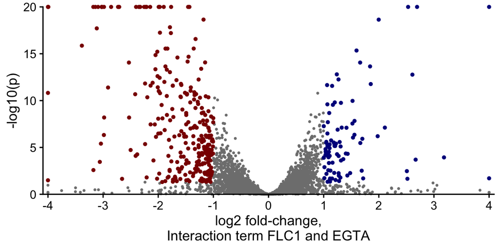

```r
volcano_FLC1EGTAinteraction <-
  ggplot(data = deseq_df_FLC1EGTAinteraction,
         aes(x = log2FC, y = -log10(padj)) ) +
  geom_point(size = 0.5, colour = "grey50") +
  geom_point(data = DEGdf_interact_up2x_FDR5,
             size = 1, colour = "darkblue") +
  geom_point(data = DEGdf_interact_down2x_FDR5,
             size = 1, colour = "darkred") +
  scale_y_continuous("-log10(p)",
                     limits = c(0,20), expand = c(0,0),
                     oob=scales::squish) +
  scale_x_continuous("log2 fold-change,\nInteraction term FLC1 and EGTA",
                     breaks = -5:5,
                     limits = c(-4,4), expand = c(0.01,0.01),
                     oob = scales::squish) +
  coord_cartesian(clip = "off")
volcano_FLC1EGTAinteraction
```

The volcano plot shows extensive differential effects of EGTA in flc1∆ compared to wild-type cells.

## Write outputs to files

```r
deseq_df_FLC1EGTAinteraction %>%
  dplyr::mutate(
    across(c(baseMean, log2FC, stderror), round, digits = 3)
  ) %>%
  dplyr::mutate(padj = signif(padj, digits = 4)) %>%
  write_tsv(file = here::here("results", "DEGs",
                              "deseq_df_FLC1EGTAinteraction.txt"))
```

```r
DEGdf_interact_up2x_FDR5 %>%
  dplyr::pull(gene) %>%
  write_lines(file = here::here("results", "DEGs",
                            "deglist_FLC1EGTAinteraction_up2x_FDR5.txt"))

DEGdf_interact_down2x_FDR5 %>%
  dplyr::pull(gene) %>%
  write_lines(file = here::here("results", "DEGs",
                            "deglist_FLC1EGTAinteraction_down2x_FDR5.txt"))
```

# Session Info